# Automated RNA-seq Workflows & Quality Control

Nov 2023

## RNA-seq Analysis Workflow

[figure not shown]

## Bioinformatic workflows

Running bioinformatic workflows can be challenging:

- Large number of software packages
- Possibly many samples to process
- Complex dependencies between analysis steps

Running such an analysis step-by-step can be tedious, error-prone and not always the most efficient.

## Workflow managing software

Workflow managers help to solve this challenge:

- Manage the running of each step of the pipeline, by feeding the output from one step to the next step
- Automatically install the necessary software for each step of the analysis
- Can run on multiple compute platforms, from a local laptop to a High Performance Compute cluster

## Nextflow

- Active community of users and developers
- Many community-developed pipelines available online
  - [**nf-core project**](https://nf-co.re/): collection of well-documented, best-practices bioinformatic workflow repositories

Check out the list of [current pipelines](https://nf-co.re/pipelines) available from this community!

## RNA-seq workflow: `nf-core/rnaseq`

Best-practices workflow for RNA-seq data processing (up to expression quantification).

[figure not shown]

## RNA-seq workflow: `nf-core/rnaseq`

Best-practices workflow for RNA-seq data processing (up to expression quantification):

- **Quality control** of raw reads using *FastQC*.
- **Adapter removal** and **quality trimming** using *Trim Galore!*.
- **Quantification** of gene expression using *Salmon*.
- **Alignment** of reads to a reference genome using *STAR* → allows to extract **quality metrics** of interest.

[figure not shown]

## `nf-core/rnaseq`: the samplesheet

Before analysis prepare a CSV file with information about each sample:

```
sample,fastq_1,fastq_2,strandedness
SRR7657872,fastq/SRR7657872_1.fastq.gz,fastq/SRR7657872_2.fastq.gz,auto
SRR7657874,fastq/SRR7657874_1.fastq.gz,fastq/SRR7657874_2.fastq.gz,auto
SRR7657876,fastq/SRR7657876_1.fastq.gz,fastq/SRR7657876_2.fastq.gz,auto
SRR7657877,fastq/SRR7657877_1.fastq.gz,fastq/SRR7657877_2.fastq.gz,auto
```

- Sample name
- Path to read 1 FASTQ file
- Path to read 2 FASTQ file
- Type of library, if known (stranded or unstranded)

**Check the [usage documentation](https://nf-co.re/rnaseq/latest/docs/usage)!**

## How to run `nf-core/rnaseq`

```bash
nextflow run nf-core/rnaseq \
  -r 3.19.0 -profile singularity \
  --input data/nextflow_samplesheet.csv \
  --outdir results/rnaseq \
  --fasta "$PWD/references/Mus_musculus.GRCm38.dna_sm.primary_assembly.fa.gz" \
  --gtf "$PWD/references/Mus_musculus.GRCm38.102.gtf.gz" \
  --aligner star_salmon \
  --extra_salmon_quant_args "--seqBias --gcBias" \
  --skip_deseq2_qc
```

Note that the `\` is used to split the command across multiple lines. Make sure that there is **no space** after the `\` symbol, otherwise it will break the code!

## `nf-core/rnaseq`: running

Pipeline progress is printed to the screen

```
[c6/11e749] process > NFCORE_RNASEQ:RNASEQ:PREPARE_GENOME:GUNZIP_GTF (Mus_musculus.GRCm38.102.gtf.gz) [100%] 1 of 1 ✔
[-        ] process > NFCORE_RNASEQ:RNASEQ:PREPARE_GENOME:GTF2BED                                     [  0%] 0 of 1
[-        ] process > NFCORE_RNASEQ:RNASEQ:PREPARE_GENOME:GTF_GENE_FILTER                             [  0%] 0 of 1
[-        ] process > NFCORE_RNASEQ:RNASEQ:PREPARE_GENOME:MAKE_TRANSCRIPTS_FASTA                       -
[67/d7d69c] process > NFCORE_RNASEQ:RNASEQ:PREPARE_GENOME:CUSTOM_GETCHROMSIZES (Mus_musculus.GRCm3... [100%] 1 of 1 ✔
[-        ] process > NFCORE_RNASEQ:RNASEQ:PREPARE_GENOME:STAR_GENOMEGENERATE                         [100%] 1 of 1 ✔
[e3/59b09a] process > NFCORE_RNASEQ:RNASEQ:INPUT_CHECK:SAMPLESHEET_CHECK (nextflow_samplesheet.csv)   [100%] 1 of 1 ✔
[-        ] process > NFCORE_RNASEQ:RNASEQ:CAT_FASTQ                                                  -
[-        ] process > NFCORE_RNASEQ:RNASEQ:FASTQ_SUBSAMPLE_FQ_SALMON:SALMON_INDEX                     -
[c2/c0caca] process > NFCORE_RNASEQ:RNASEQ:FASTQ_SUBSAMPLE_FQ_SALMON:FQ_SUBSAMPLE (SRR7657874)        [ 16%] 2 of 12
[-        ] process > NFCORE_RNASEQ:RNASEQ:FASTQ_SUBSAMPLE_FQ_SALMON:SALMON_QUANT                     -
[-        ] process > NFCORE_RNASEQ:RNASEQ:FASTQ_FASTQC_UMITOOLS_TRIMGALORE:FASTQC                    -
[-        ] process > NFCORE_RNASEQ:RNASEQ:FASTQ_FASTQC_UMITOOLS_TRIMGALORE:TRIMGALORE                -
[-        ] process > NFCORE_RNASEQ:RNASEQ:ALIGN_STAR:STAR_ALIGN                                      [  8%] 1 of 2
```

## `nf-core/rnaseq`: running

Once complete:

```
-[nf-core/rnaseq] Pipeline completed successfully-
Completed at: 18-May-2022 08:08:25
Duration    : 4h 13m
CPU hours   : 8.1
Succeeded   : 343
```

## `nf-core/rnaseq`: outputs

- **MultiQC report**: quality control report; located in `multiqc/star_salmon/multiqc_report.html`.
- **Transcript quantification**: tabular files generated by *Salmon*; located in `star_salmon/<SAMPLE NAME>/quant.sf`.
- **Coverage tracks**: bigWig files that can be used for visualisation in IGV; located in `star_salmon/bigwig/`.

## `nf-core/rnaseq`: exercise

**Link to full exercise**

For this exercise, we will use small FASTQ files for 4 of our samples and run them through the `nf-core/rnaseq` workflow. This is so the pipeline completes within a reasonable time.

Make sure the pipeline starts running without any apparent errors, printing its progress on the screen. It will take some time to run, so you can leave it running to complete. We will look at its outputs in the next section.

## Alignment-based quality control

Why perform alignment if *Salmon* is so fast?

Although expression quantification can be quickly done with *Salmon*’s pseudo-alignment algorithm, aligning reads to the genome allows us to extract several quality metrics of interest:

- Alignment rates
- Read duplication rates
- Gene body coverage
- Complexity curves

## Alignment rate

Depends on:

- Quality of Reference Genome
- Quality of library prep and sequencing
- For human and mouse > 95%

`nf-core/rnaseq` workflow allows to check for:

- Contamination from a suspected organism (e.g. human) → uses *BBSplit* software
- Presence of ribossomal RNA in total RNA library protocols (i.e. not polyA-enriched) → uses *SortMeRNA* software

## Read duplication

Duplicate reads are reads that come from the same DNA fragment (or cDNA, in the case of RNA-seq).

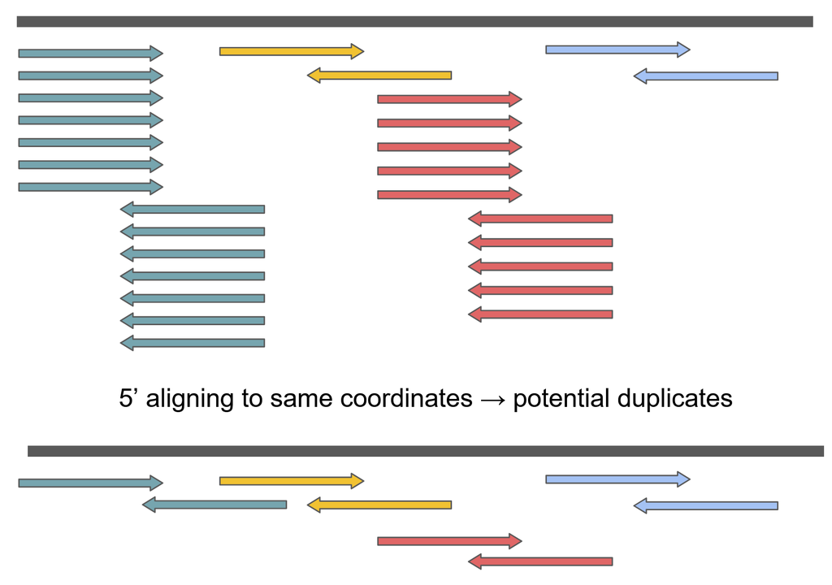

Bioinformatically *inferred* as reads aligning to the same coordinates of the reference genome.

## Read duplication

In RNA-seq not as trivial as the chances of reads aligning to the same coordinates increases as:

- We are only sequencing a fraction of the genome (transcripts)
- Some transcripts might be highly expressed (many reads align to a restricted region)

For example the human exome is ~30 Mb therefore there are < 30 million possible reads.

Duplication rates in RNAseq can be > 40%, therefore duplicate removal in RNA-seq is generally not recommended.

## Read duplication: `dupRadar`

R/Bioconductor package [`dupRadar`](https://bioconductor.org/packages/release/bioc/vignettes/dupRadar/inst/doc/dupRadar.html) considers the relationship between transcript length, transcript expression level and duplicate rates.

[figure not shown]

## Transcript coverage

Expect uniform distribution of reads along the gene body, with no bias towards the 5’ or 3’ ends.

A 3’ bias may indicate poor RNA quality due to RNA degradation.

[figure not shown]

## Junction saturation

Would more sequencing be beneficial?

Splice site saturation plot gives an indication if more sequencing would be beneficial: known junctions plateau early, while novel junctions need deeper coverage.

[figure not shown]

## QC Goals

- Ensure the experiment generated the expected data
- Check if the sequencing depth and alignment rates are similar across samples
- Identify poor alignment parameters (sample quality, library prep, something else?)
- Discover contamination from another organism or from DNA
- Identify biases present in the data

## Exercise

**Link to full exercise**

We’ve pre-processed several samples through the `nf-core/rnaseq` pipeline. The results can be found in `preprocessed/rnaseq` on the course materials folder.

Open the MultiQC report and answer the following questions:

1. Was the quality of the raw reads good? Were there any reads with adapter contamination?
2. What was the fraction of reads mapped to the reference genome? Were there any samples with mapping rates below 90%?
3. Was there evidence of RNA degradation for any of the samples?
4. Would these samples have benefited from more sequencing?